# Analysis of BSE Intraday Returns

Meghana Yerabati

22 August, 2017

# Problem Statement

We aim to find the distribution of intraday returns of institutional traders and retail traders by studying the the bse tradebook to deduce the patterns of wealth transfer amongst institutional and retail intraday traders.

# Results

A short analysis for data of five days is given below.

The dataset consists of 8 columns:

| Schema | Description |
| --- | --- |
| date | Date on which the trade occured |
| trader | BSE client code |
| symbol | BSE Scrip Code for the stock |
| cat | BSE client category |
| buy_vol | total volume of a given stock bought by the client on the given date |
| sell_vol | total volume of a given stock sold by the client on the given date |
| vwap_sell | calculation explained below |
| vwap_buy | calculation explained below |

The methodology for calculation of Volume Weighted Average Price (VWAP) of a given stock for a given trader is as follows:

$$VWAP_{buy}= \dfrac{\Sigma\,vol_{buy}*P_{buy}}{\Sigma \,vol_{buy} }$$

$$VWAP_{sell}= \dfrac{\Sigma\,vol_{sell}*P_{sell}}{\Sigma \,vol_{sell} }$$

## January 3rd, 2005

### Data Overview

**Total number of partial intraday transactions:** 102500

**Total number of pure intraday transactions:** 78534

*All statistics from here on are computed for pure intraday trades only.*

**Unique number of stocks traded:** 1621

**Unique number of traders:** 30363

### Trader categories and count in intraday trading

```
##    category count        prop%
## 4         I 25150 81.756712828
## 7       NaN  4035 13.116832456
## 2        CO   611  1.986216761
## 3       HUF   407  1.323060919
## 10        O   303  0.984981471
## 12       PF   123  0.399843963
## 13       SP    81  0.263311878
## 1         0    34  0.110525974
## 6        MF    14  0.045510695
## 5        MB     1  0.003250764
## 8       NRI     1  0.003250764
## 9        NT     1  0.003250764
## 11      OCB     1  0.003250764
```

### Total volume traded per category after removing duplicates in intraday trading

```
##    cat  buy_vol sell_vol   buy_vol_prop  sell_vol_prop
## 4    I 44805399 44805399 0.734587401646 0.734587401646
## 2   CO 10188587 10188587 0.167042539913 0.167042539913
## 6  NaN  2208205  2208205 0.036203663162 0.036203663162
## 3  HUF  1537066  1537066 0.025200296042 0.025200296042
## 9    O   844760   844760 0.013849894594 0.013849894594
## 11  PF   637457   637457 0.010451148561 0.010451148561
## 1    0   444365   444365 0.007285392788 0.007285392788
## 12  SP   194183   194183 0.003183642789 0.003183642789
## 8   NT    68664    68664 0.001125750701 0.001125750701
## 5   MF    64480    64480 0.001057153752 0.001057153752
## 7  NRI      500      500 0.000008197532 0.000008197532
## 10 OCB      300      300 0.000004918519 0.000004918519
```

### Analysing the institutional and retail traders returns

**Normalize returns earned by the traders:**

We normalize the returns earned by the traders with respect to volume in the following way:

$$Normalized \, Returns= \dfrac{Total\,volume\,weighted \,logarithmic\,returns\,earned\,by\, the\,trader}{Total\, volume\, traded\, by\, the\, trader}$$

$$Normalized \, Returns=\dfrac{\Sigma log(VWAP_{sell}/VWAP_{buy})*min(vol_{buy},vol_{sell}))}{\Sigma\,min(vol_{buy},vol_{sell}) }$$

We run the analysis only for category types ‘Individual’ or ‘I’ and ‘Company’ or ‘CO’ where the former are retail traders and the latter are institutional traders.

**1. Institutional Traders**

The total no. of institutional traders is `505`.

We plot a smooth density estimate[^1] as follows:

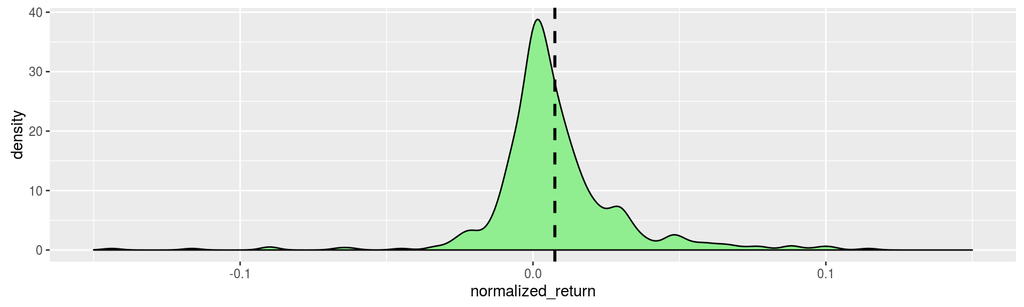

**2. Retail Traders**

The total no. of retail traders is `24799`.

We plot a smooth density estimate as follows:

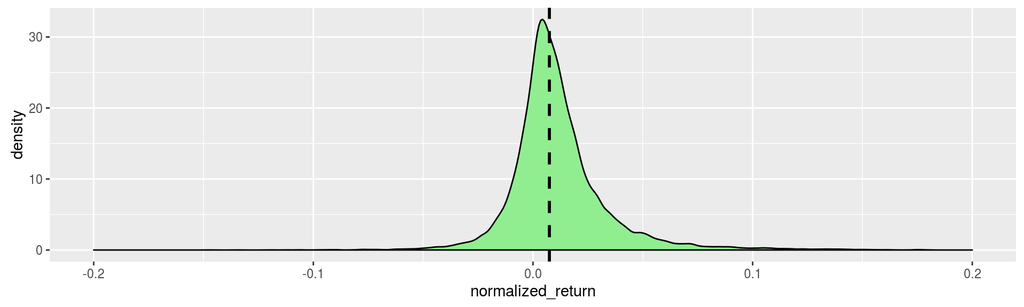

### Comparing normalized returns of Institutional trader and Retail trader

```
##                          institutional           retail
## No. of observations     505.0000000000 24799.0000000000
## No. of NAs                0.0000000000     0.0000000000
## Mean                      0.0074695121     0.0114606877
## Median                    0.0040941986     0.0080552795
## Max                       0.1145234286     0.2518193513
## Min                      -0.1438305647    -0.3360697411
## Range                     0.2583539933     0.5878890924
## Variance                  0.0005295135     0.0005144543
## Std Dev                   0.0230111601     0.0226815852
## Coeff of Variation in % 308.0677814674   197.9077149001
## Std. Error                0.0010239832     0.0001440311
```

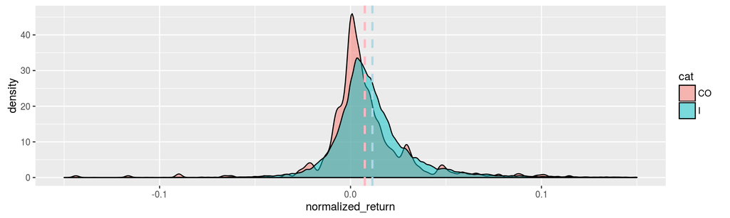

**Q-Q Plot:**

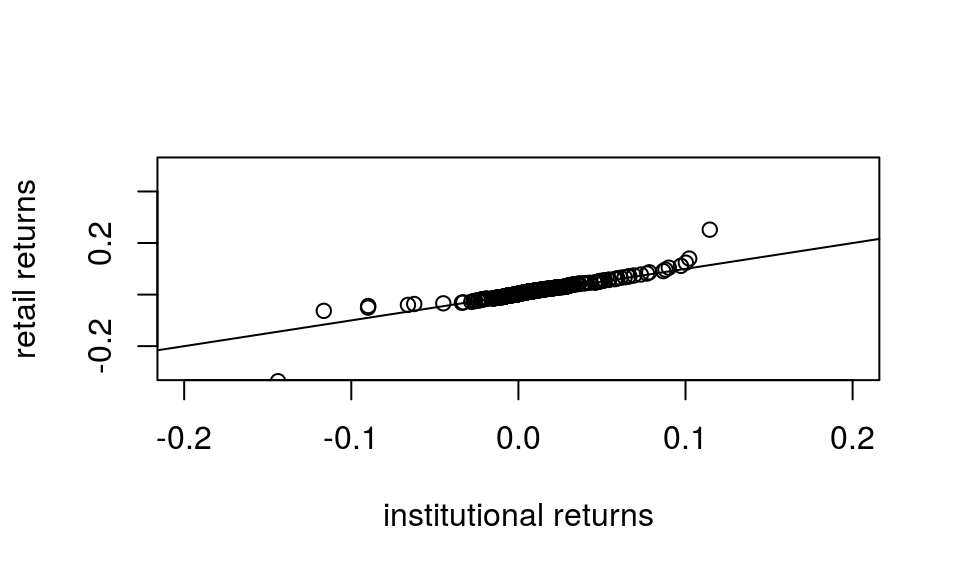

## January 4th, 2005

### Data Overview

**Total number of partial intraday transactions:** 110047

**Total number of pure intraday transactions:** 85749

*All statistics from here on are computed for pure intraday trades only.*

**Unique number of stocks traded:** 1689

**Unique number of traders:** 32225

### Trader categories and count

```
##    category count        prop%
## 7         I 26696 81.684107460
## 9       NaN  4291 13.129551435
## 4        CO   655  2.004161312
## 6       HUF   449  1.373844930
## 12        O   315  0.963833303
## 14       PF   143  0.437549722
## 15       SP    80  0.244783061
## 1         0    36  0.110152377
## 8        MF    11  0.033657671
## 2       AOP     1  0.003059788
## 3         B     1  0.003059788
## 5       FII     1  0.003059788
## 10      NRI     1  0.003059788
## 11       NT     1  0.003059788
## 13      OCB     1  0.003059788
```

*includes 418 traders having multiple categories which we remove from our analysis

### Total volume traded per category

```
##    cat  buy_vol sell_vol    buy_vol_prop   sell_vol_prop
## 5    I 51976131 51976131 0.7245573409939 0.7245573409939
## 3   CO 13357107 13357107 0.1862006606704 0.1862006606704
## 7  NaN  2407963  2407963 0.0335674709703 0.0335674709703
## 4  HUF  1288722  1288722 0.0179650344809 0.0179650344809
## 12  PF   832048   832048 0.0115989104010 0.0115989104010
## 10   O   746953   746953 0.0104126696065 0.0104126696065
## 1    0   742327   742327 0.0103481822698 0.0103481822698
## 13  SP   285148   285148 0.0039750183920 0.0039750183920
## 6   MF    57410    57410 0.0008003065281 0.0008003065281
## 9   NT    40705    40705 0.0005674355901 0.0005674355901
## 11 OCB      250      250 0.0000034850485 0.0000034850485
## 2    B      200      200 0.0000027880388 0.0000027880388
## 8  NRI       50       50 0.0000006970097 0.0000006970097
```

### Analysing the institutional and retail traders returns

**Normalize returns earned by the traders:**

We normalize the returns earned by the traders with respect to volume as mentioned previously

We run the analysis only for category types ‘Individual’ or ‘I’ and ‘Company’ or ‘CO’ where the former are retail traders and the latter are institutional traders.

**1. Institutional Traders**

The total no. of institutional traders is 538.

We plot a smooth density estimate as follows:

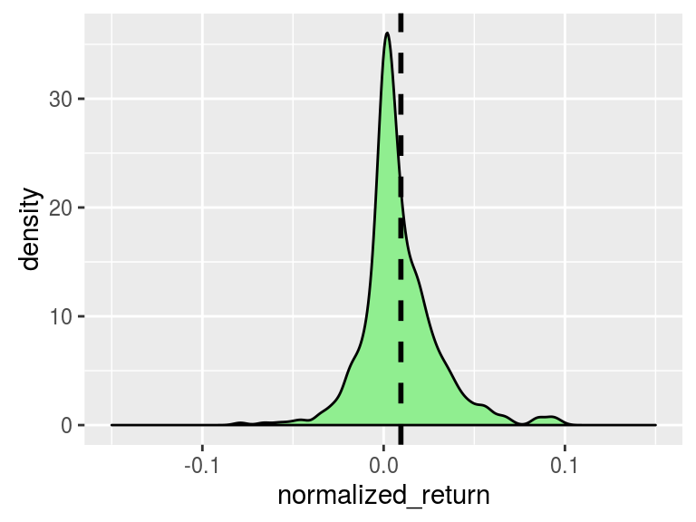

**2. Retail Traders**

The total no. of retail traders is 26296.

We plot a smooth density estimate as follows:

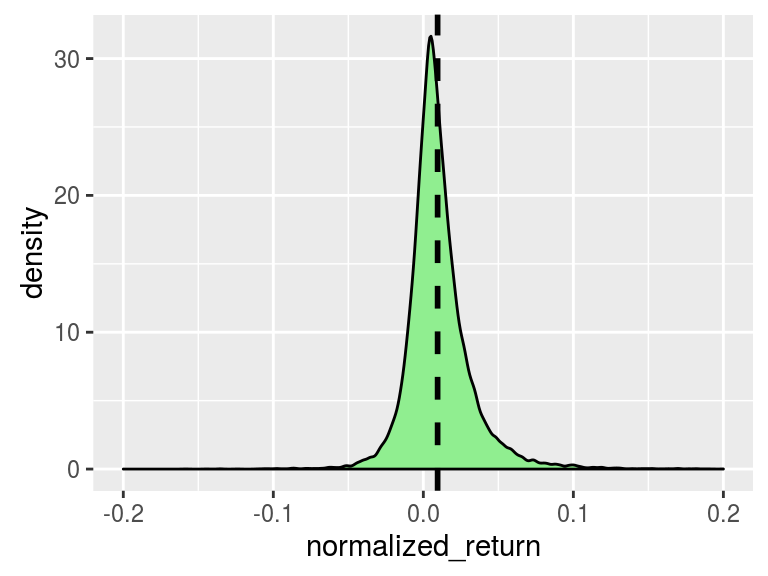

### Comparing normalized returns of Institutional trader and Retail trader

```
##                          institutional           retail
## No. of observations     538.0000000000 26296.0000000000
## No. of NAs                0.0000000000     0.0000000000
## Mean                      0.0095116122     0.0102285957
## Median                    0.0043517055     0.0073934924
## Max                       0.2265943805     0.2384110234
## Min                      -0.0789758783    -0.1582979123
## Range                     0.3055702588     0.3967089358
## Variance                  0.0006232881     0.0004675438
## Std Dev                   0.0249657376     0.0216227612
## Coeff of Variation in % 262.4764018482   211.3952096003
## Std. Error                0.0010763494     0.0001333418
```

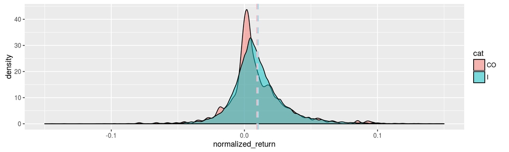

**Q-Q Plot:**

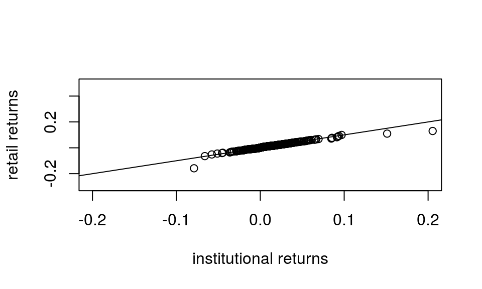

## January 5th, 2005

### Data Overview

**Total number of partial intraday transactions:** 138810

**Total number of pure intraday transactions:** 101192

*All statistics from here on are computed for pure intraday trades only.*

**Unique number of stocks traded:** 1739

**Unique number of traders:** 39363

### Trader categories and count

```
##    category count        prop%
## 5         I 32323 80.833770976
## 7       NaN  5625 14.067071798
## 2        CO   766  1.915622577
## 4       HUF   609  1.522994973
## 10        O   352  0.880286093
## 12       PF   161  0.402630855
## 13       SP   104  0.260084527
## 1         0    30  0.075024383
## 6        MF    12  0.030009753
## 9        NT     2  0.005001626
## 3       FII     1  0.002500813
## 8       NRI     1  0.002500813
## 11      OCB     1  0.002500813
```

*includes 575 traders having multiple categories which we remove from our analysis

### Total volume traded per category

```
##    cat  buy_vol sell_vol   buy_vol_prop  sell_vol_prop
## 5    I 62365305 62365305 0.735149568050 0.735149568050
## 2   CO 14157304 14157304 0.166883428540 0.166883428540
## 7  NaN  3602567  3602567 0.042466329218 0.042466329218
## 4  HUF  1437958  1437958 0.016950357295 0.016950357295
## 1    0  1208546  1208546 0.014246095163 0.014246095163
## 10   O   911064   911064 0.010739437674 0.010739437674
## 13  SP   548509   548509 0.006465712858 0.006465712858
## 12  PF   463337   463337 0.005461722594 0.005461722594
## 6   MF    70237    70237 0.000827939512 0.000827939512
## 9   NT    67584    67584 0.000796666486 0.000796666486
## 8  NRI      500      500 0.000005893899 0.000005893899
## 3  FII      331      331 0.000003901761 0.000003901761
## 11 OCB      250      250 0.000002946949 0.000002946949
```

### Analysing the institutional and retail traders returns

**Normalize returns earned by the traders:**

We normalize the returns earned by the traders with respect to volume as mentioned previously

We run the analysis only for category types ‘Individual’ or ‘I’ and ‘Company’ or ‘CO’ where the former are retail traders and the latter are institutional traders.

**1. Institutional Traders**

The total no. of institutional traders is 617.

We plot a smooth density estimate as follows:

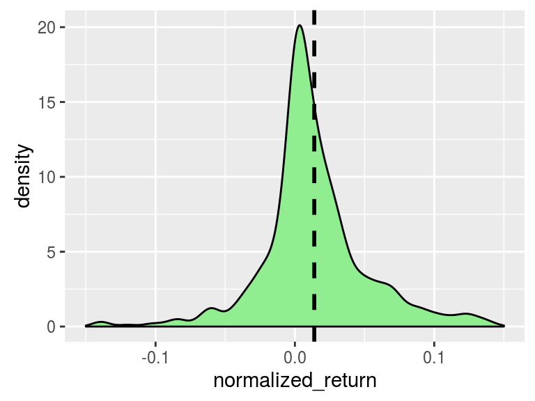

**2. Retail Traders**

The total no. of retail traders is 31780.

We plot a smooth density estimate as follows:

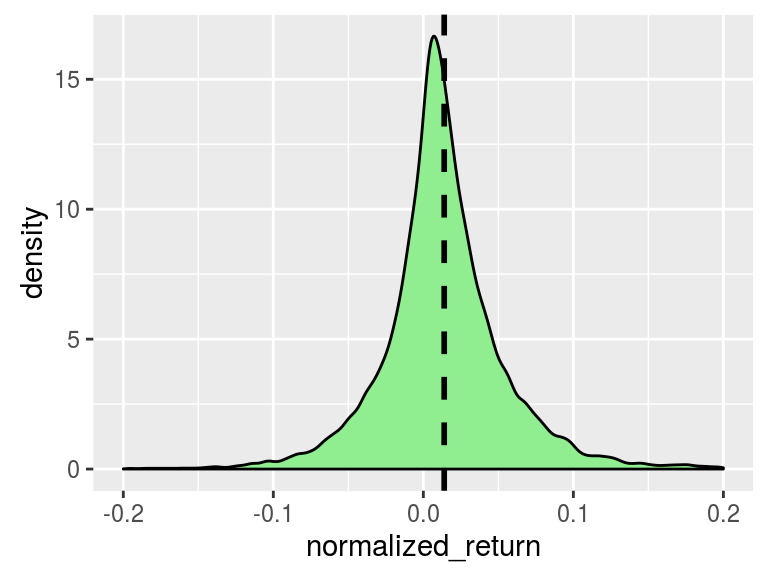

### Comparing normalized returns of Institutional trader and Retail trader

```
##                         institutional           retail
## No. of observations     617.000000000 31780.0000000000
## No. of NAs                0.000000000     0.0000000000
## Mean                      0.013901665     0.0135643087
## Median                    0.008098534     0.0107658619
## Max                       0.406162245     0.4478858240
## Min                      -0.206785578    -0.6061539889
## Range                     0.612947823     1.0540398129
## Variance                  0.002260415     0.0019177497
## Std Dev                   0.047543819     0.0437921197
## Coeff of Variation in % 342.000907526   322.8481510050
## Std. Error                0.001914042     0.0002456513
```

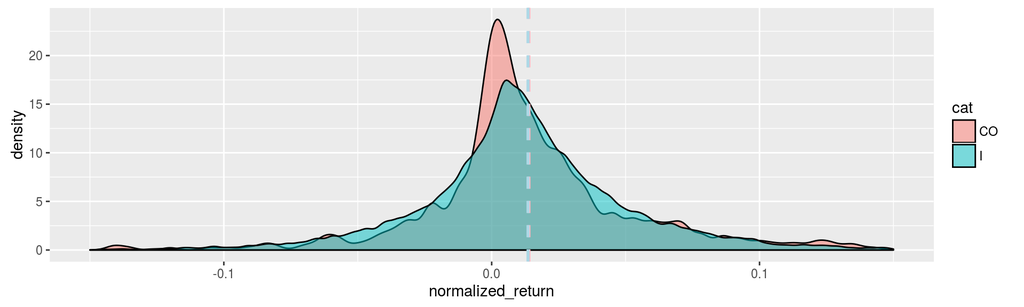

**Q-Q Plot:**

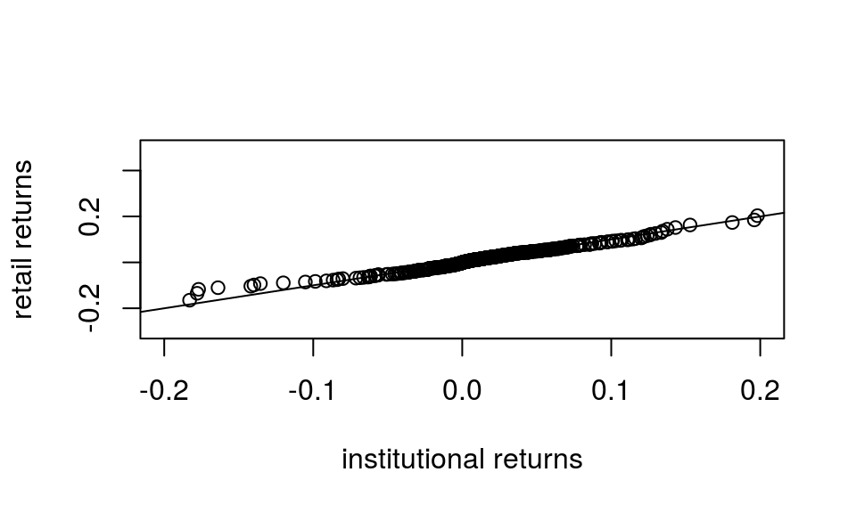

## January 6th, 2005

### Data Overview

**Total number of partial intraday transactions:** 134130

**Total number of pure intraday transactions:** 106669

*All statistics from here on are computed for pure intraday trades only.*

**Unique number of stocks traded:** 1710

**Unique number of traders:** 38181

### Trader categories and count

```
##    category count        prop%
## 5         I 31555 81.396548611
## 7       NaN  5276 13.609513246
## 3        CO   711  1.834034101
## 4       HUF   554  1.429050481
## 10        O   362  0.933783888
## 11       PF   158  0.407563134
## 12       SP    94  0.242474269
## 1         0    32  0.082544432
## 6        MF    17  0.043851730
## 8       NRI     5  0.012897568
## 9        NT     2  0.005159027
## 2       AOP     1  0.002579514
```

*includes 547 traders having multiple categories which we remove from our analysis.

### Total volume traded per category

```
##    cat  buy_vol sell_vol  buy_vol_prop sell_vol_prop
## 5    I 61681554 61681554 0.74277115106 0.74277115106
## 3   CO 13387913 13387913 0.16121765592 0.16121765592
## 7  NaN  3539100  3539100 0.04261794994 0.04261794994
## 1    0  1424292  1424292 0.01715136762 0.01715136762
## 4  HUF  1050523  1050523 0.01265042995 0.01265042995
## 10   O   892457   892457 0.01074699436 0.01074699436
## 11  PF   654380   654380 0.00788006388 0.00788006388
## 12  SP   283331   283331 0.00341188053 0.00341188053
## 6   MF   104201   104201 0.00125479161 0.00125479161
## 9   NT    19523    19523 0.00023509656 0.00023509656
## 8  NRI     2700     2700 0.00003251348 0.00003251348
## 2  AOP     2500     2500 0.00003010508 0.00003010508
```

### Analysing the institutional and retail traders returns

**Normalize returns earned by the traders**

We normalize the returns earned by the traders with respect to volume as mentioned previously

We run the analysis only for category types ‘Individual’ or ‘I’ and ‘Company’ or ‘CO’ where the former are retail traders and the latter are institutional traders.

**1. Institutional Traders**

The total no. of institutional traders is 581.

We plot a smooth density estimate as follows:

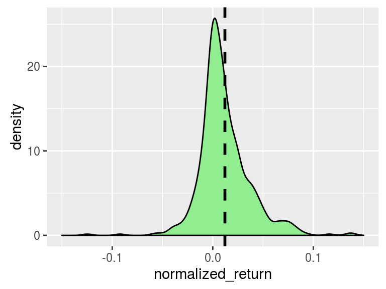

**2. Retail Traders**

The total no. of retail traders is 31037.

We plot a smooth density estimate as follows:

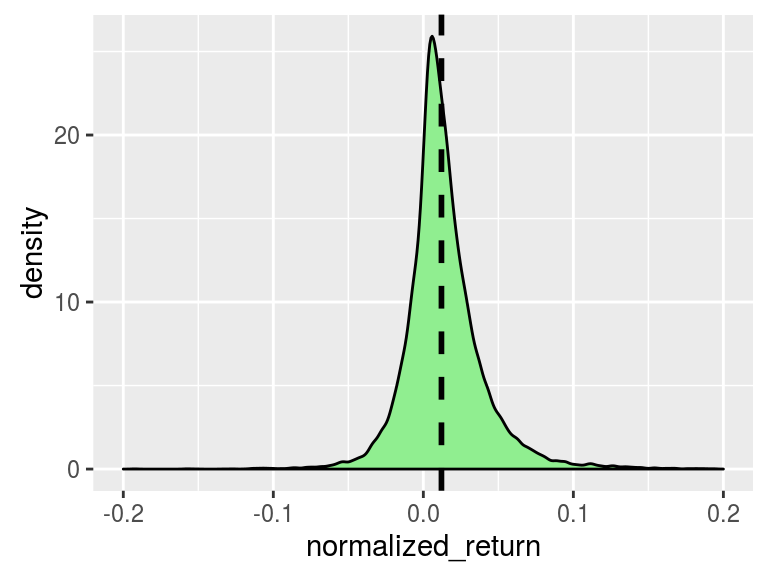

### Comparing normalized returns of Institutional trader and Retail trader

```
##                          institutional           retail
## No. of observations     581.0000000000 31037.0000000000
## No. of NAs                0.0000000000     0.0000000000
## Mean                      0.0120714966     0.0135941894
## Median                    0.0073775738     0.0103811541
## Max                       0.2691056869     0.2821110274
## Min                      -0.1248043986    -0.2031114271
## Range                     0.3939100854     0.4852224545
## Variance                  0.0007495782     0.0006931006
## Std Dev                   0.0273784251     0.0263268046
## Coeff of Variation in % 226.8022437021   193.6621874388
## Std. Error                0.0011358485     0.0001494370
```

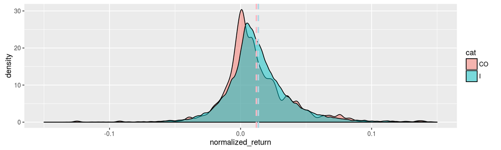

**Q-Q Plot:**

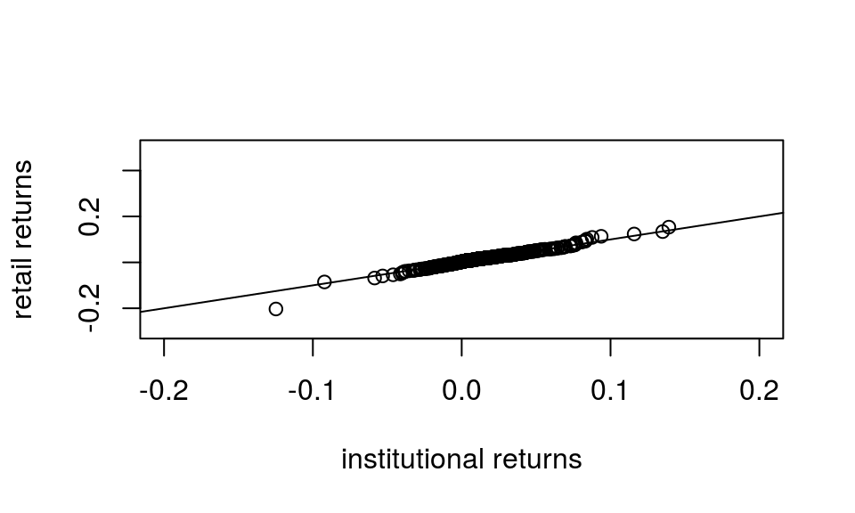

## January 7th, 2005

### Data Overview

**Total number of partial intraday transactions:** 103932

**Total number of pure intraday transactions:** 85086

*All statistics from here on are computed for pure intraday trades only.*

**Unique number of stocks traded:** 1649

**Unique number of traders:** 32060

### Trader categories and count

```
##    category count        prop%
## 5         I 26689 82.137691195
## 8       NaN  4169 12.830455790
## 3        CO   607  1.868094667
## 4       HUF   441  1.357215400
## 11        O   309  0.950974056
## 13       PF   135  0.415474102
## 14       SP    86  0.264672391
## 1         0    32  0.098482750
## 7        MF    19  0.058474133
## 10       NT     2  0.006155172
## 2       AOP     1  0.003077586
## 6        MB     1  0.003077586
## 9       NRI     1  0.003077586
## 12      OCB     1  0.003077586
```

*includes 406 traders having multiple categories which we remove from our analysis

### Total volume traded per category

```
##    cat  buy_vol sell_vol    buy_vol_prop   sell_vol_prop
## 5    I 44159017 44159017 0.7349528330691 0.7349528330691
## 3   CO 10564370 10564370 0.1758262341096 0.1758262341096
## 8  NaN  2149754  2149754 0.0357790526157 0.0357790526157
## 1    0   947723   947723 0.0157732610718 0.0157732610718
## 4  HUF   759134   759134 0.0126345132180 0.0126345132180
## 11   O   702457   702457 0.0116912195364 0.0116912195364
## 13  PF   400265   400265 0.0066617401318 0.0066617401318
## 14  SP   186612   186612 0.0031058440020 0.0031058440020
## 7   MF   175562   175562 0.0029219352704 0.0029219352704
## 10  NT    33857    33857 0.0005634930250 0.0005634930250
## 2  AOP     5000     5000 0.0000832166206 0.0000832166206
## 12 OCB      250      250 0.0000041608310 0.0000041608310
## 9  NRI      100      100 0.0000016643324 0.0000016643324
## 6   MB       50       50 0.0000008321662 0.0000008321662
```

### Analysing the institutional and retail traders returns

**Normalize returns earned by the traders:**

We normalize the returns earned by the traders with respect to volume as mentioned previously

We run the analysis only for category types ‘Individual’ or ‘I’ and ‘Company’ or ‘CO’ where the former are retail traders and the latter are institutional traders.

**1. Institutional Traders**

The total no. of institutional traders is 508.

We plot a smooth density estimate as follows:

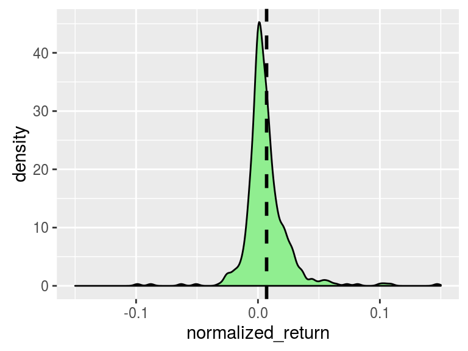

**2. Retail Traders**

The total no. of retail traders is 26301.

We plot a smooth density estimate as follows:

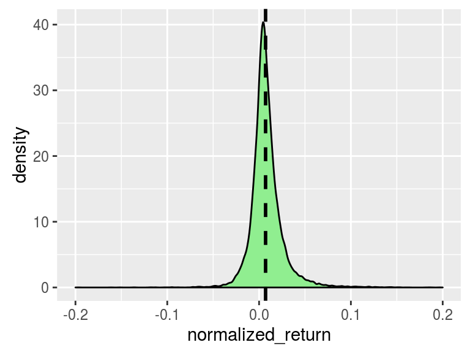

### Comparing normalized returns of Institutional trader and Retail trader

```
##                          institutional           retail
## No. of observations     508.0000000000 26301.0000000000
## No. of NAs                0.0000000000     0.0000000000
## Mean                      0.0070843812     0.0082743281
## Median                    0.0039515790     0.0060683518
## Max                       0.3074846997     1.4250088733
## Min                      -0.0989014253    -0.1967102942
## Range                     0.4063861251     1.6217191675
## Variance                  0.0005217297     0.0004457154
## Std Dev                   0.0228414031     0.0211119724
## Coeff of Variation in % 322.4191722252   255.1502931595
## Std. Error                0.0010134234     0.0001301795
```

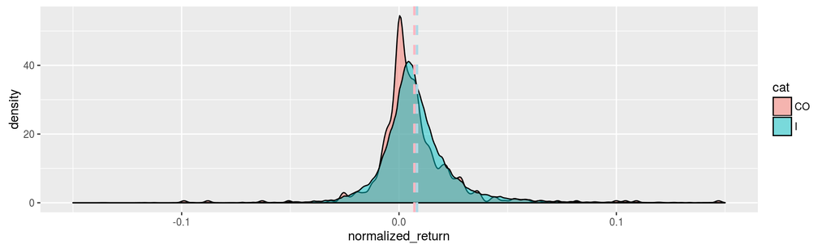

**Q-Q Plot:**

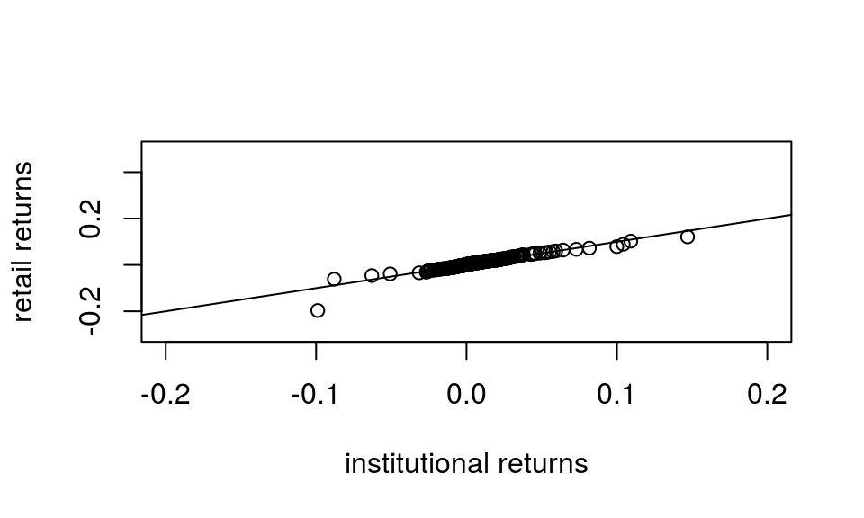

[^1]: A kernel density estimate is used to display the distribution of variables with underlying smoothness using geom_density in ggplot2 with the default kernel being “gaussian”. The bandwidth of a Gaussian kernel density estimator defaults to 0.9 times the minimum of the standard deviation and the interquartile range divided by 1.34 times the sample size to the negative one-fifth power (= Silverman’s ‘rule of thumb’, Silverman (1986, page 48, eqn (3.31)) unless the quartiles coincide when a positive result will be guaranteed. Bandwidh adjusting factor is 0.5